# Diamonds

Amjad Darwish

3/15/2017

## Introduction

This document will examine the nature of diamond **pricing** when wieghed against things like **Carats**, **Color**, **Cut**, and **Clarity**.

## Price Relative to Carats

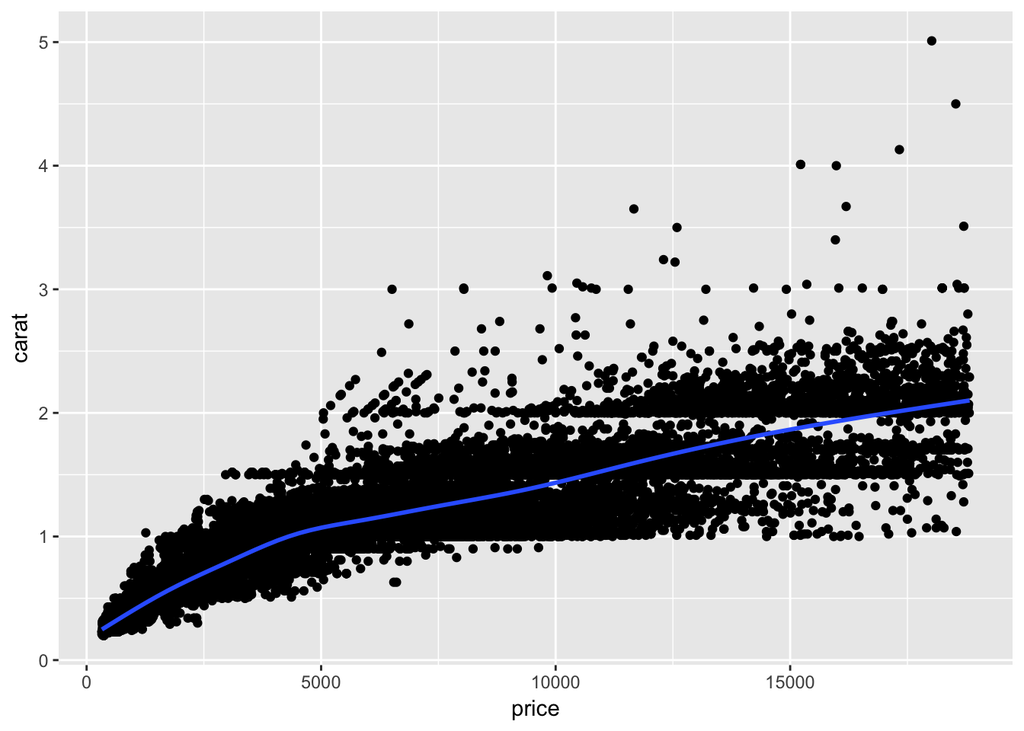

Looking at the data this way will be very difficult for us due to the huge data points it includes. We need to filter and play around with the dataset to be able to come to any meaningful conclusions.

## Common Colors

Let’s first start off with colors. We would want to focus on the most used or common diamond colors. Below is a graph that shows the number of diamonds presented by each color.

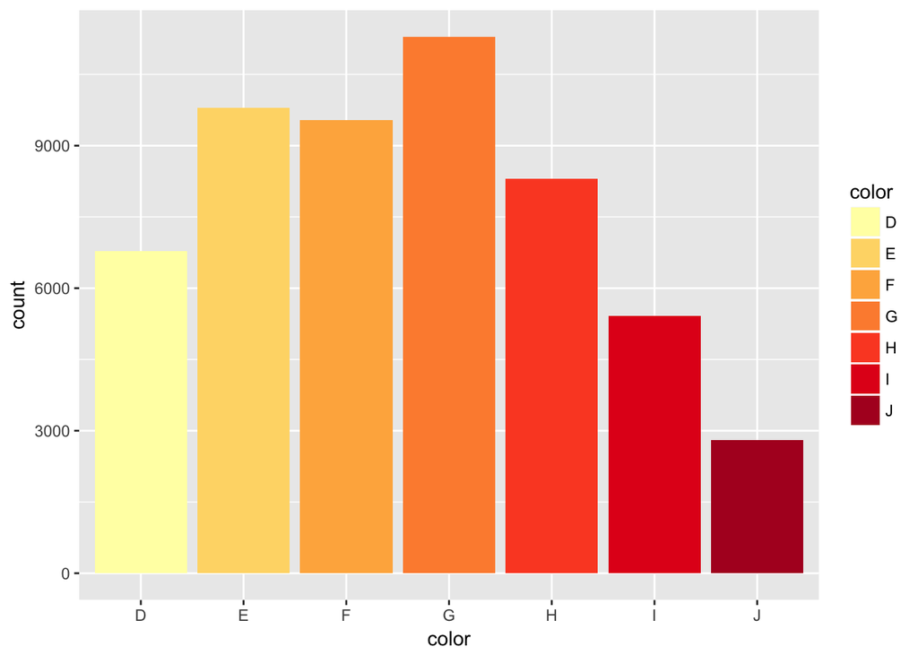

As shown in the above graph, the most common diamond colors in the market are *E*, *F*, and *G*. Let’s try and explore more information regarding those specific colors.

## Premium Cuts

Diving deeper into the three colors we talked about earlier, we can conclude from the graph below that the most common cut for all of them is the ideal cut, which ranks as the **highest quality** cut there is.

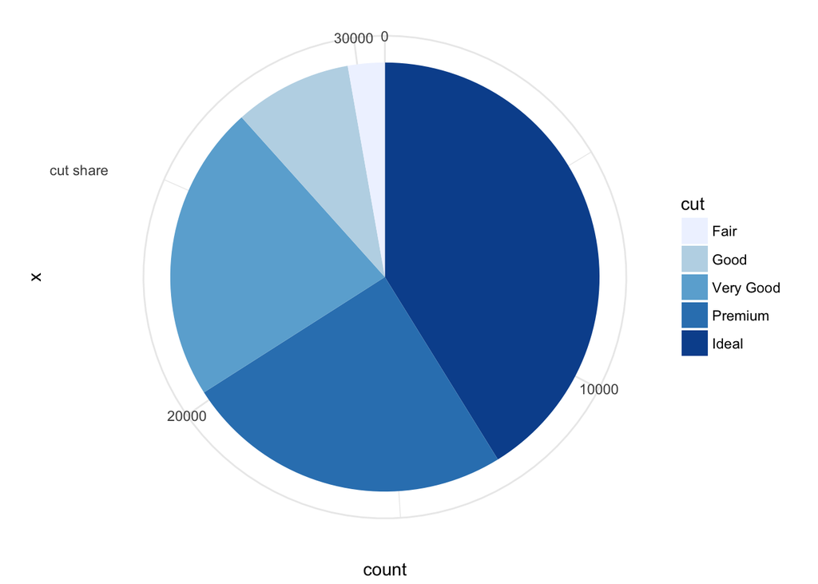

Further asserting that notion is the fact that, as mentioned below, these three colors are cut mostly in *Ideal*.

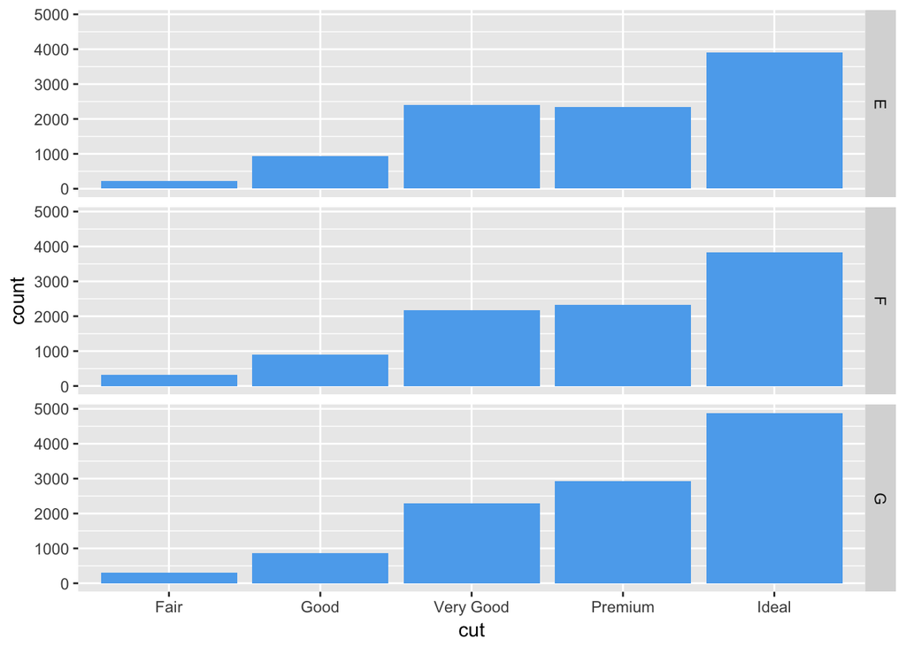

## Clarity Levels

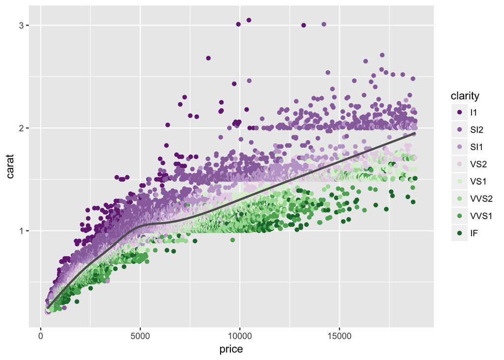

Looking at the chart above, it is still includes a lot of data points for us to make a fair assumption about the diamonds price compared to their clarity. In this section, we will try to narrow down the data by only including the most common clarity levels.

The clarity levels for the colors and cuts we chose are shown in the graph below:

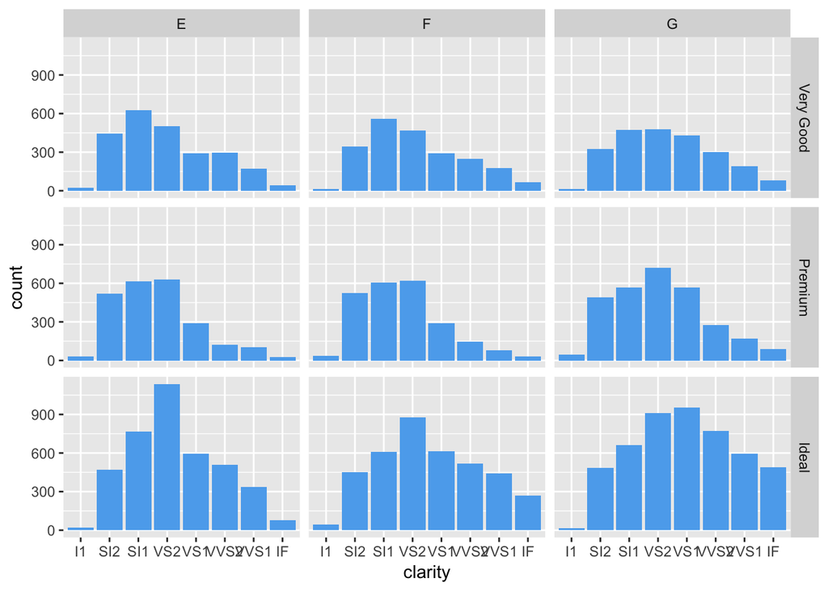

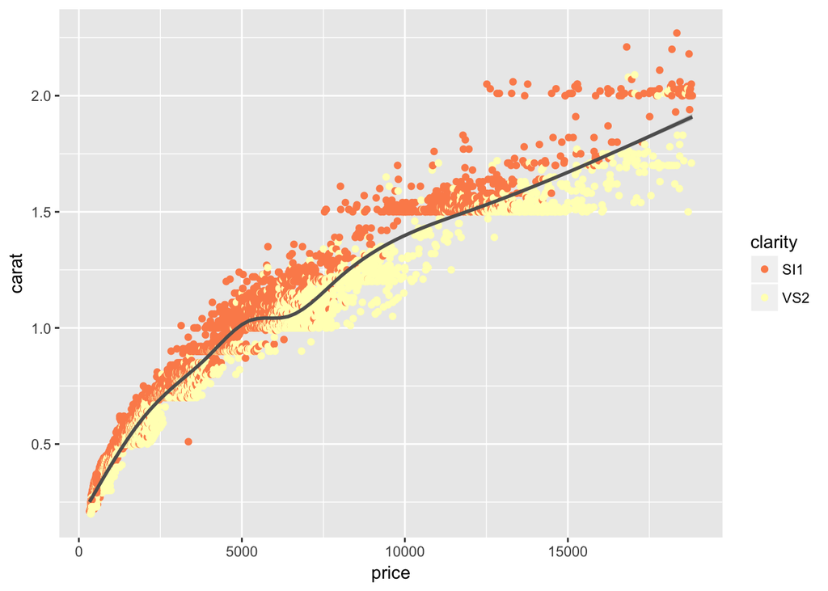

## Final Iterations

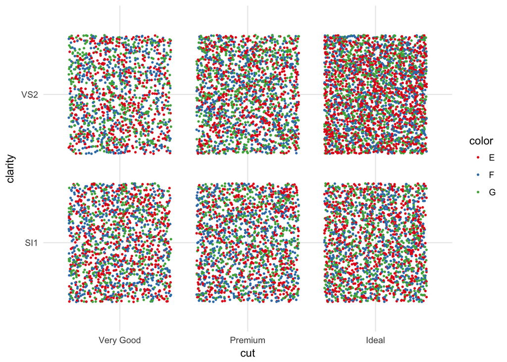

## Conclusions

Examining the effects of color on price after filtering down to one cut and one clarity level.

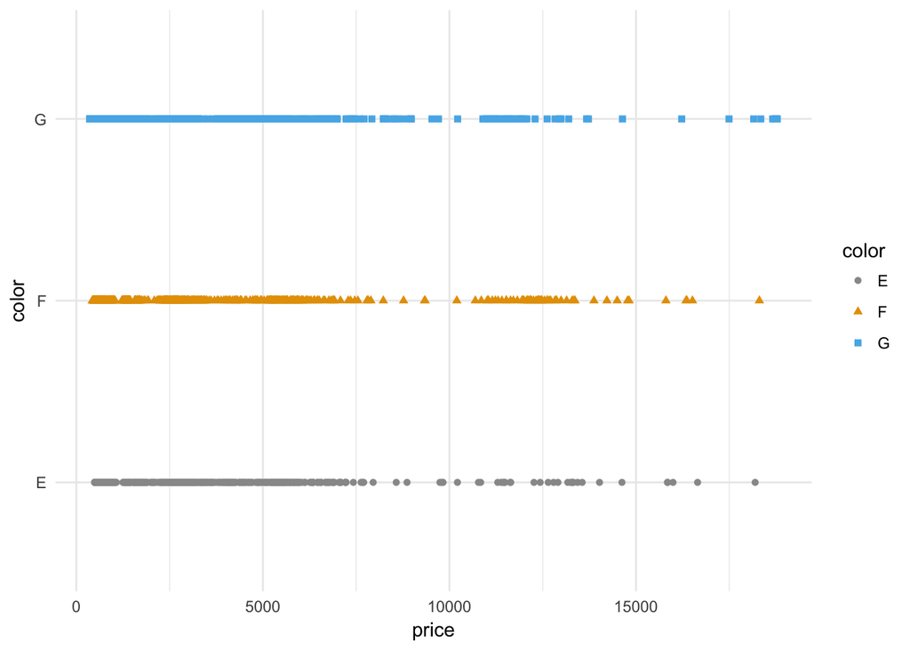